# El modelado y la predicción de procesos en redes

Alejandro Urrego Lopez

Bryan Camilo Riveros Guarnizo

Cesar Augusto Prieto Sarmiento

2024-05-23

## 1 Introducción

En el estudio de redes, se suele priorizar los **atributos nodales** sobre las relaciones entre nodos, ya que atributos como **comportamientos, creencias o estados de salud** pueden ser influenciados por las **interacciones dentro de la red**. Ejemplos clave incluyen:

-**Influencia de interacciones en comportamientos y creencias**-**Riesgo de contagio en contextos de salud**

Estos ejemplos tratan los atributos nodales como **procesos estocásticos**, es decir, **colecciones de variables aleatorias** que describen la evolución de un sistema en el tiempo o espacio. En una red, estos procesos se definen sobre un grafo $G = (V, E)$, con $V$ como nodos y $E$ como aristas. Las variables aleatorias $\vec{X}$ están indexadas por los nodos, así:

- $\{X_i\}$ para $i \in V$: **proceso estático**.
- $\{X_i(t)\}$, con $t$ en el tiempo: **proceso dinámico**.

En este cuaderno, se considera $\vec{X}$ un **vector binario** donde indica la presencia del **atributo de interés** y su ausencia.

## 2 Método del vecino más cercano

El método del vecino más cercano es una técnica simple para predecir atributos nodales usando la información de los nodos adyacentes. Antes de explicarlo, es importante definir tres conceptos clave:

-**Colección de Atributos Nodales**: $\{X_i\}$ representa un atributo estático, es decir, que no cambia con el tiempo. - **Vecindad**: $\mathcal{N}_i$ es el conjunto de nodos conectados directamente al nodo $i$ en el grafo $G$. -**Número de Vecinos**: $\left|\mathcal{N}_i\right|$ es la cantidad de vecinos del nodo $i$.

La **predicción del atributo** de $i$ se realiza calculando el promedio de los atributos de sus vecinos más cercanos:

$$\frac{\sum_{j \in \mathcal{N}_i} x_j}{|\mathcal{N}_i|},$$

donde:

- $\sum_{j \in \mathcal{N}_i} x_j$ es la suma de los atributos de los vecinos de $i$.
- $\left|\mathcal{N}_i\right|$ es el número de vecinos de $i$.

Para una **predicción binaria** (es decir, $X_i = 1$ o $X_i = 0$), se compara el promedio con un **umbral**, usualmente 0.5:

- Si el promedio es **mayor a 0.5**, se predice $X_i = 1$.
- Si es **menor o igual a 0.5**, se predice $X_i = 0$.

### Ejemplo Ilustrativo

En una **red social**, $X_i$ podría indicar si una persona $i$ está interesada en un tema específico (1 para sí, 0 para no). Para predecir si una persona está interesada:

1.**Contamos** el número de amigos interesados. 2.**Dividimos** por el total de amigos. 3.**Comparamos** con el umbral de 0.5.

Si el promedio supera 0.5, se predice que $i$ está interesada; de lo contrario, no lo está.

Así funciona el método del vecino más cercano.

## 2.1 Ejemplo red de proteínas y Método del vecino más cercano

Red de **proteínas** que pertenecen a la levadura de panadería **Saccharomyces cerevisiae**, reunidas por Jiang et al. de diversas fuentes con descripción de algunas funcionalidades y atributos de las proteínas. El atributo nodal *ICSC* es un vector binario que indica aquellas proteínas que tienen como **función “cascada de señalización intracelular”** (*ICSC*), una forma específica de comunicación celular.

```r
# semilla para garantizar reproducibilidad
set.seed(42)
# Importancion de la libreria sand y los datos ppi.CC
suppressMessages(suppressWarnings(library(sand)))
suppressMessages(data(ppi.CC))
```

```r
# resumen del objeto tipo igrap ppi.cc
summary(ppi.CC)
```

```
## IGRAPH 3e8c8b7 UN-- 134 241 --
## + attr: name (v/c), ICSC (v/n), IPR000198 (v/n), IPR000403 (v/n),
## | IPR001806 (v/n), IPR001849 (v/n), IPR002041 (v/n), IPR003527 (v/n)
```

```r
# visualización de los 10 primeros valores del Vector ICSC
V(ppi.CC)$ICSC[1:10]
```

```
##  [1] 1 1 1 1 1 0 1 1 1 1
```

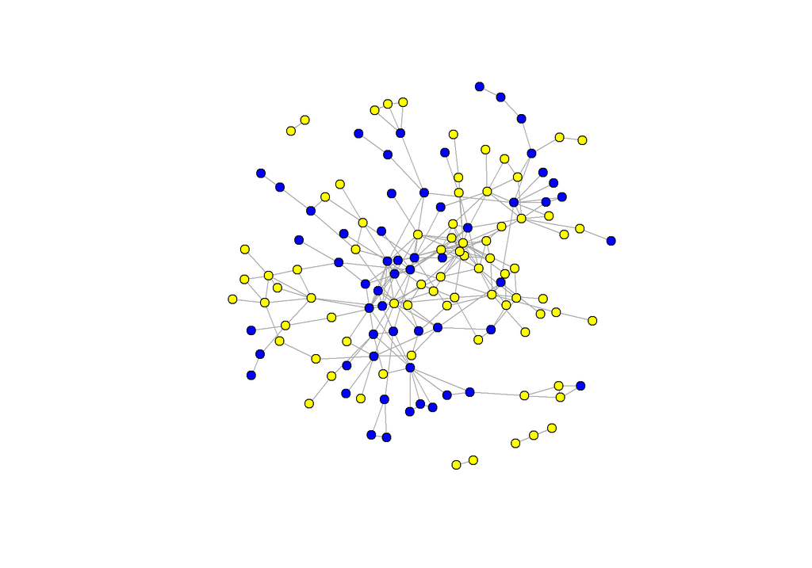

```r
# asignación de colores a las proteínas en base a su función
 V(ppi.CC)[ICSC == 1]$color <- "yellow"
 V(ppi.CC)[ICSC == 0]$color <- "blue"
 # gráfico de la red de proteínas
plot(ppi.CC, vertex.size=5, vertex.label=NA)
```

```r
# cálculo del coeficiente de asortatividad
assortativity_nominal(ppi.CC, as.numeric(as.factor(V(ppi.CC)$ICSC)), directed = FALSE)
```

```
## [1] 0.3818884
```

```r
# componente gigante
clu <- components(ppi.CC)
# grafo de la componente gigante
ppi.CC.gc <- induced_subgraph(ppi.CC,
   clu$membership==which.max(clu$csize))
# cálculo promedio del vecino más cercano
nn.ave <- sapply(V(ppi.CC.gc),
   function(x) mean(V(ppi.CC.gc)[.nei(x)]$ICSC))
```

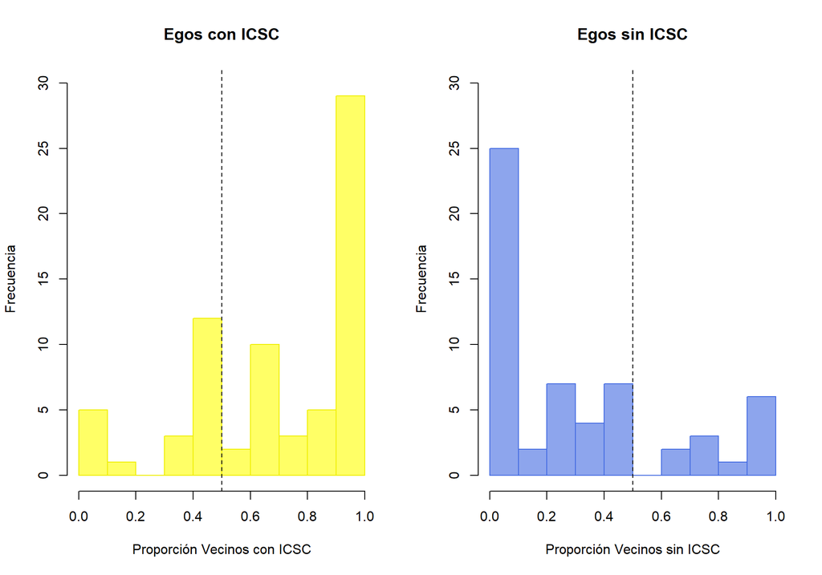

```r
par(mfrow=c(1,2))
hist(nn.ave[V(ppi.CC.gc)$ICSC == 1], col = adjustcolor('yellow', 0.6), border = "yellow2",
   ylim=c(0, 30), breaks = 10, ylab = "Frecuencia", xlab="Proporción Vecinos con ICSC",
   main="Egos con ICSC")
abline(v=0.5, col="black", lty=2)
hist(nn.ave[V(ppi.CC.gc)$ICSC == 0], col = adjustcolor('royalblue', 0.6), border = "royalblue",
   ylim=c(0, 30), breaks = 10, ylab = "Frecuencia", xlab="Proporción Vecinos sin ICSC",
   main="Egos sin ICSC")
abline(v=0.5, col="black", lty=2)
```

```r
par(mfrow=c(1,1))
```

```r
# predicción del vecino más cercano
nn.pred <- as.numeric(nn.ave > 0.5)
# cálculo de la tasa de error
print(mean(as.numeric(nn.pred != V(ppi.CC.gc)$ICSC)))
```

```
## [1] 0.2598425
```

```r
# importación de los datos de las proteínas actualizadas
x <- as.list(org.Sc.sgdGO2ALLORFS)
current.icst <- x[names(x) == "GO:0035556"]
ev.code <- names(current.icst[[1]])
icst.ida <- current.icst[[1]][ev.code == "IDA"]
```

Aquí, **current.icst** contiene las proteínas asociadas con la cascada de señalización intracelular (ICSC) identificadas por el código GO **GO:0035556**, y **icst.ida** filtra aquellas proteínas con evidencia del tipo **“IDA”**.

```r
# nombres de las proteínas que tienen ICSC en la componente gigante
orig.icsc <- V(ppi.CC.gc)[ICSC == 1]$name
```

```r
# nombres de todas las proteínas que contienen ICSC
candidates <- intersect(icst.ida, V(ppi.CC.gc)$name)
```

```r
# nombre de las proteínas nuevas que contienen ICSC
new.icsc <- setdiff(candidates, orig.icsc)
new.icsc
```

```
## [1] "YBL016W" "YDL159W" "YDL235C" "YER020W" "YIL033C" "YIL147C" "YLR006C"
## [8] "YLR362W"
```

Aquí, **candidates** contiene todas las proteínas actualizadas que coinciden con los nombres en la componente gigante, y **new.icsc** identifica aquellas proteínas que son nuevas, es decir, que no estaban **previamente catalogadas** como ICSC en la componente gigante.

```r
# predicciones de las proteinas que antes no se sabia que tenian ICSC
nn.ave[V(ppi.CC.gc)$name %in% new.icsc]
```

```
##   YIL033C   YLR362W   YDL159W   YLR006C   YER020W   YBL016W   YDL235C   YIL147C
## 0.7500000 0.4166667 0.3333333 0.6666667 0.1111111 0.2500000 0.0000000 0.0000000
```

El método del **vecino más cercano** puede **generalizarse** mediante la construcción de un modelo estadístico apropiado, lo que permitirá hacer **predicciones más precisas**. Este modelo puede incluir **variables** tanto **endógenas** como **exógenas** de la red.

## 3 Campos aleatorios de Markov

Sea $G=(V,E)$ un grafo y $\mathbf{X}=(X_1,X_2,\dots,X_{N_V})^T$ una colección de variables aleatorias definidas en $V$. Se dirá que $\mathbf{X}$ es un campo aleatorio de Markov en $G$ si:

$$\begin{align*}
&P(X=x) > 0 \text{ para todos los posibles valores de } x, \\
&P(X_i=x_i|X_{-i}=x_{-i}) =
P(X_i=x_i|X_{\mathcal{N}_i}=x_{\mathcal{N}_i}),
\end{align*}$$

donde $X_{-i} = (X_1, X_2, \dots, X_{i-1}, X_{i+1}, \dots, X_{N_V})$ y $X_{\mathcal{N}_i}$ es el vector de todos los $X_j$ para $j$ en $\mathcal{N}_i$. **El concepto de MRF puede verse como una generalización de una cadena de Markov.**

Una característica clave que facilita el uso práctico de los campos aleatorios de Markov es que su **distribución asociada** se puede expresar como:

$$P(X=x) = \left(\frac{1}{\kappa}\right)\exp\left\{U(x)\right\},$$

donde:

- $U(\cdot)$ es conocida como función de energía.
- $\kappa$ es la función partición.

La función $U(\cdot)$ se puede expresar como
$$U(x) = \sum_{\mathcal{C} \in C} U_{\mathcal{C}}(x)$$

- con $\mathcal{C}$ el conjunto de todos los clanes en $G$.

lo que permite simplificar los cálculos si se tienen los siguientes supuestos:

- $U_{\mathcal{C}}$ no depende de la posición del clan.
- clanes de tamaño limitado, por lo general uno y dos.

### 3.1 Modelos Auto Logísticos

Al hacer los siguientes supuestos:

- Solo los **clanes** $c \in \mathcal{C}$ de **tamaño uno o dos** tienen funciones de energía $U_c$ distintas de cero.
- Las **probabilidades condicionales** tienen una forma de la **familia exponencial**.

$$U(x) = \sum_{i \in V} x_i H_i(x_i) +
\sum_{\{i,j\} \in E} \beta_{ij} x_i x_j$$

Los modelos con esta función de energía son llamados **modelos auto** por Besag.

Ahora, si se supone que $X_i$ es una variable binaria,

$$U(x) = \sum_{i \in V} \alpha_i x_i +
\sum_{\{i,j\} \in E} \beta_{ij} x_i x_j$$

El modelo MRF resultante es llamado modelo **autologístico** debido a que si se asume que $\alpha_i \equiv \alpha$ y $\beta_{ij} \equiv \beta$ la probabilidad condicional se puede expresar como:

$$P(X_i=1|X_\mathcal{N_i}=x\mathcal{N_i}) =
\frac{exp(\alpha_i+\sum_{j\in\mathcal{N_i}}\beta_{ij}x_j)}{1+exp(\alpha_i+\sum_{j\in\mathcal{N_i}}\beta_{ij}x_j)}$$

$$\log \left( \frac{P(X_i = 1 \mid
X_{\mathcal{N}_i} = x_{\mathcal{N}_i})}{P(X_i = 0 \mid X_{\mathcal{N}_i}
= x_{\mathcal{N}_i})} \right) = \log \left( \frac{P(X_i = 1 \mid
X_{\mathcal{N}_i} = x_{\mathcal{N}_i})}{1 - P(X_i = 1 \mid
X_{\mathcal{N}_i} = x_{\mathcal{N}_i})} \right) = \alpha + \beta \sum_{j
\in \mathcal{N}_i} x_j$$

Si se desea incorporar variables exógenas el modelo se puede ver como:

$$\log \frac{\mathbb{P}_{\alpha,\beta} \left( X_i = 1 \mid
\mathbf{X}_{\mathcal{N}_i} = \mathbf{x}_{\mathcal{N}_i}, \mathbf{Z}_i =
\mathbf{z}_i \right)}{\mathbb{P}_{\alpha,\beta} \left( X_i = 0 \mid
\mathbf{X}_{\mathcal{N}_i} = \mathbf{x}_{\mathcal{N}_i}, \mathbf{Z}_i =
\mathbf{z}_i \right)} = \mathbf{z}_i^T \alpha + \beta \sum_{j \in
\mathcal{N}_i} (x_j - \mu_j),$$

$\mu_j = \{1 + \exp(-\mathbf{z}_j^T \alpha)\}^{-1}$ es el valor esperado de $X_j$ bajo independencia, es decir, cuando $\beta=0$.

### 3.2 Estimación de los parámetros

A diferencia del método del vecino más cercano, para este modelo se necesita estimar algunos parámetros que, en este caso, para el modelo auto logístico son $\alpha$ y $\beta$.

Al estimar estos parámetros por el método de **máxima verosimilitud**, se obtiene que es el valor que maximiza la expresión:

$$\alpha M_1(x) + \beta M_{11}(x) -
\kappa(\alpha, \beta),$$

donde:

- $M_1(x)$ es el número de vértices que tienen el atributo, es decir, la variable $x_i = 1$.
- $M_{11}(x)$ es el doble del número de pares de vértices donde ambos tienen el atributo, en otras palabras, donde $x_i = x_j = 1$ para alguna arista $(i, j) \in G$.
- $\kappa(\alpha, \beta)$ es la función de partición.

La función $\kappa$ hace que la **estimación sea muy demandante computacionalmente**, por lo tanto, esta maximización se hace mediante el **método denominado pseudo-máxima verosimilitud**, originalmente propuesto por Besag para el análisis de datos espaciales, la cual es este caso es una aproximación usada pare reducir el impacto computacional. Resultando en que la estimación de la pseudo-verosimilitud es el valor que maximiza la siguiente expresión:

$$\alpha M_1(x) + \beta M_{11}(x) -
\sum_{i=1}^{N_V} \log \left[ 1 + \exp\left( \alpha + \beta \sum_{j \in
\mathcal{N}_i} x_j \right) \right].$$

### 3.3 Ejemplo red de proteínas y Modelo Auto Logístico

```r
suppressMessages(suppressWarnings(library(ngspatial)))
```

Las variables endógenas en un grafo son aquellas que se derivan de la estructura interna de la red. Es decir, dependen exclusivamente de las propiedades del grafo mismo, estas se resumen bajo el paramtro $\eta$ .

ejemplos:

```r
# se asigna la correspondiente forma a un modelo mrf que no tiene atributos nodales
formula1 <- X~1
```

Las variables exógenas son aquellas que se introducen desde fuera del sistema de la red y no dependen directamente de la estructura del grafo, pero pueden influir en la formación o el comportamiento de la red, en este caso las propiedades de las levaduras a trabajar.

```r
# se toman característica de la red asociadas con cada nodo
gene.motifs <- cbind(V(ppi.CC.gc)$IPR000198, # vectores binarios
                     V(ppi.CC.gc)$IPR000403,
                     V(ppi.CC.gc)$IPR001806,
                     V(ppi.CC.gc)$IPR001849,
                     V(ppi.CC.gc)$IPR002041,
                     V(ppi.CC.gc)$IPR003527)
# se asigna la correspondiente forma a un modelo mrf que tiene atributos nodales
formula <- X ~ gene.motifs
```

```r
# se toma el atributos nodal que se desea predecir
X <- V(ppi.CC.gc)$ICSC
# matriz de adyacencia
A <- as_adjacency_matrix(ppi.CC.gc, sparse=FALSE)
```

```r
# modelo autologistico sin atributos nodales
m1.mrf <- autologistic(formula1, A=A,
                       control=list(confint="none"))
```

```r
# estimaciones
m1.mrf$coefficients
```

```
## (Intercept)         eta
##   0.2004949   1.1351942
```

```r
# vector booleano que marca verdadero si se supera el umbral
mrf1.pred <- as.numeric((m1.mrf$fitted.values > 0.5))
```

```r
# cálculo de la tasa de error
mean(as.numeric(mrf1.pred != V(ppi.CC.gc)$ICSC))
```

```
## [1] 0.2047244
```

```r
# predicciones de las proteinas que antes no se sabia que tenian ICSC
m1.mrf$fitted.values[V(ppi.CC.gc)$name %in% new.icsc]
```

```
## [1] 0.75191425 0.16586471 0.21840915 0.64518969 0.01361227 0.07422185 0.25958629
## [8] 0.39560481
```

```r
# modelo auto logístico con atributos nodales
m2.mrf <- autologistic(formula, A=A,
                       control=list(confint="none"))
```

```r
# estimaciones
m2.mrf$coefficients
```

```
##   (Intercept)  gene.motifs1  gene.motifs2  gene.motifs3  gene.motifs4
##  5.081573e-02  1.876848e+00  1.875217e+01  1.875217e+01  1.824990e+01
##  gene.motifs5  gene.motifs6           eta
##  8.487244e-08 -1.837997e+01  1.297921e+00
```

```r
# vector booleano que marca verdadero si se supera el umbral
# cálculo de la tasa de error
mrf.pred2 <- as.numeric((m2.mrf$fitted.values > 0.5))
mean(as.numeric(mrf.pred2 != V(ppi.CC.gc)$ICSC))
```

```
## [1] 0.1889764
```

```r
# predicciones de las proteinas que antes no se sabia que tenian ICSC
m2.mrf$fitted.values[V(ppi.CC.gc)$name %in% new.icsc]
```

```
## [1] 7.829254e-01 4.715219e-01 4.962188e-01 6.570828e-01 3.525067e-02
## [6] 7.163338e-10 2.175373e-01 3.510037e-01
```

### 3.4 Bondad Y ajuste

Una de las maneras de evaluar la bondad de ajuste del modelo es mediante la simulación. Por lo tanto, dado un modelo MRF ajustado, se realiza simulación del proceso $X_i$ a partir de este modelo. Luego se calculan varias estadísticas que resumen las características de estas realizaciones y se comparan los resultados con los datos originales.

```r
set.seed(42)
# numero de intentos
ntrials <- 100
a1.mrf <- numeric(ntrials)
a2.mrf <- numeric(ntrials)
# intercepto
Z1 <- rep(1,length(X))
# matriz que tiene intercepto y atributos nodales
Z2 <- cbind(Z1, gene.motifs)
# simulación
for(i in 1:ntrials){
  # simular red unicamente con intercepto
  X1.mrf <- rautologistic(as.matrix(Z1), A=A,
                          theta=m1.mrf$coefficients)
  # simular red que tiene intercepto y atributos nodales
  X2.mrf<- rautologistic(as.matrix(Z2), A=A,
                         theta=m2.mrf$coefficients)
  #asortatividad
  a1.mrf[i] <- assortativity(ppi.CC.gc, X1.mrf+1,
                             directed=FALSE)
  a2.mrf[i] <- assortativity(ppi.CC.gc, X2.mrf+1,
                             directed=FALSE)
}
```

```r
# asortatividad de la red original
assortativity(ppi.CC.gc, X+1, directed=FALSE)
```

```
## [1] 0.3739348
```

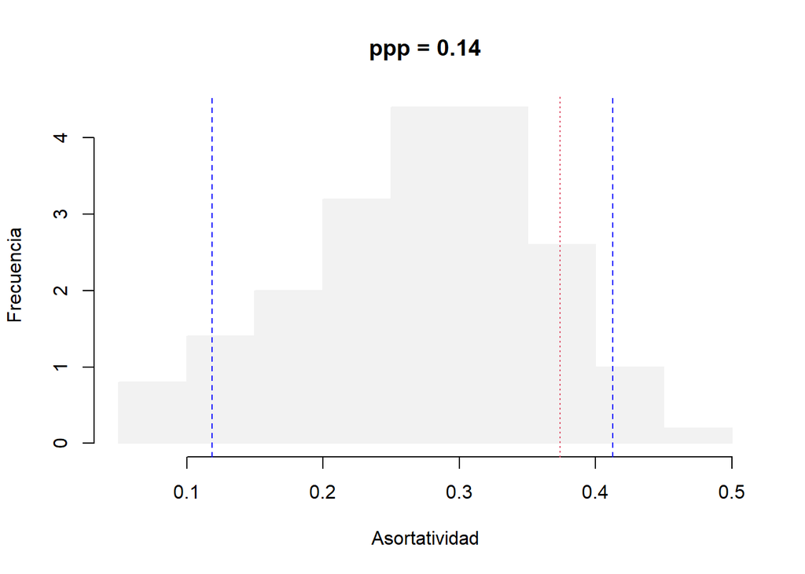

```r
hist(x = a1.mrf, freq = FALSE, col = "gray95", border = "gray95",
     xlab = 'Asortatividad', ylab = "Frecuencia",
     main = paste('ppp =', mean(a1.mrf >= assortativity(ppi.CC.gc, X + 1, directed = FALSE))))

abline(v = mean( assortativity(ppi.CC.gc, X + 1, directed = FALSE)), col = 2, lty = 3)
# Cuantil 0.5
abline(v = quantile(a1.mrf, 0.05), col = "blue", lty = 2)

# Cuantil 0.95
abline(v = quantile(a1.mrf, 0.95), col = "blue", lty = 2)
```

```r
summary(a1.mrf)
```

```
##    Min. 1st Qu.  Median    Mean 3rd Qu.    Max.
## 0.06736 0.22324 0.28733 0.27485 0.34203 0.46534
```

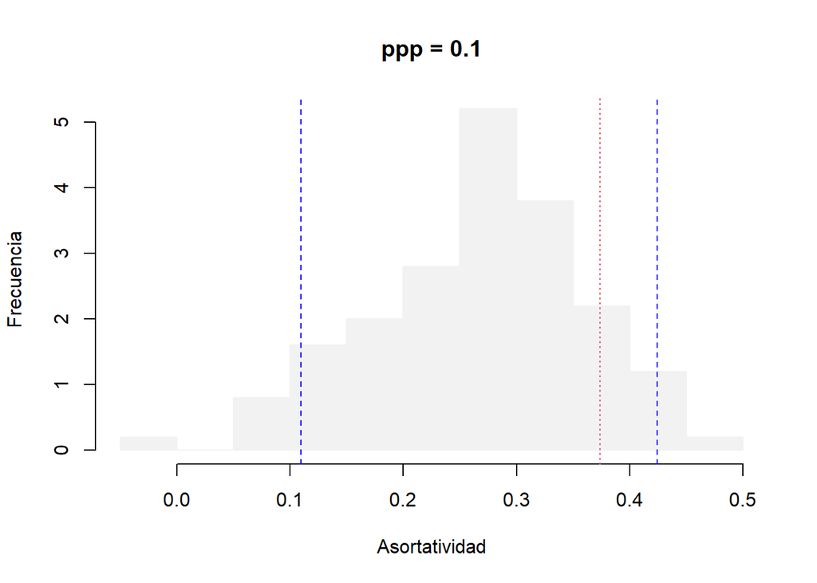

```r
hist(x = a2.mrf, freq = FALSE, col = "gray95", border = "gray95",
     xlab = 'Asortatividad', ylab = "Frecuencia",
     main = paste('ppp =', mean(a2.mrf >= assortativity(ppi.CC.gc, X + 1, directed = FALSE))))

abline(v = mean( assortativity(ppi.CC.gc, X + 1, directed = FALSE)), col = 2, lty = 3)
# Cuantil 0.5
abline(v = quantile(a2.mrf, 0.05), col = "blue", lty = 2)

# Cuantil 0.95
abline(v = quantile(a2.mrf, 0.95), col = "blue", lty = 2)
```

```r
summary(a2.mrf)
```

```
##     Min.  1st Qu.   Median     Mean  3rd Qu.     Max.
## -0.02656  0.20478  0.27621  0.26621  0.32519  0.45848
```

Para estos dos modelos, los valores predictivos posteriores de 0.14 y 0.1 sugieren que la asortatividad está siendo subestimada. Estos valores indican que, aunque los modelos son aceptables y capturan de manera razonable la estructura de asortatividad observada, no logran ajustarse perfectamente a los datos. En consecuencia, el modelo que utiliza únicamente variables endógenas podría ser el más adecuado, ya que probablemente proporciona una mejor representación de la asortatividad en comparación con los modelos que incluyen otras variables.

## 4 Método Kernel

Para relacionar vértices y atributos en un grafo, una opción es usar **métodos kernel**. Estos extienden la **regresión clásica** a datos no tradicionales, mediante:

- Variables predictivas generalizadas (codificadas en el kernel).
- Regresión penalizada sobre estos predictores.

Este enfoque complementa los modelos probabilísticos, ofreciendo una forma más explícita de construcción de relaciones en el grafo.

### 4.1 Regresión Kernel

La **regresión kernel** se aplica cuando la variable respuesta $y$ y la explicativa $x$ son continuas. Se observan $n$ pares $(x_i, y_i)$ siguiendo el modelo no paramétrico:

$$y_i = m(x_i) + \epsilon_i$$

- $\epsilon_i$ son variables independientes.
- $m(x)$ es una función regresora sin forma específica.

La función kernel $K$ que define $m(x)$ debe ser:

- Simétrica, no negativa y continua.
- Decreciente en $[0, \infty)$ y tendiendo a 0 cuando el argumento es infinito.

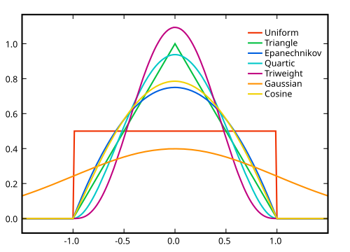

Esta función le **“asigna pesos”** a las observaciones dependiendo de la **distancia de** $x_i$ al punto $t$ donde se realiza la estimación $(x_i, y_i)$ al ser evaluado en cualquier $t$ de la variable explicativa.

El peso de $(x_i, y_i)$ en la estimación de $m(t)$ será:

$$\omega_i = \omega(t, x_i) = \frac{K\left(\frac{x_i -
t}{h}\right)}{\sum_{j=1}^n K\left(\frac{x_j - t}{h}\right)}$$

- $h$ es un parámetro de escala.

Una vez determinados los pesos $\omega_i$, se resuelve el problema de **mínimos cuadrados ponderados**:

$$\underset{\beta_0, \beta_1}{\text{arg min}} \sum_{i=1}^n \omega_i \left(
y_i - (\beta_0 + \beta_1 (x_i - t)) \right)^2$$

La recta de regresión ajustada localmente alrededor de $t$ es:

$$l_t(x) = \beta_0 + \beta_1 (x - t)$$

y la estimación de la función de regresión en el punto $t$ es el valor que toma esta recta en $x = t$:

$$\hat{m}(t) = l_t(t) = \beta_0$$

Para extender la **regresión kernel** al caso en el que hay $p$ regresores, es directo:

$$y_i = m(x_{i1}, \dots, x_{ip}) + \epsilon_i$$

Ahora, para definir la **función de regresión**, se necesita definir los pesos de cada $\omega_i$ de cada observación.

La definición de los pesos $\omega_i$ debe seguir la **misma lógica que en el caso univariado**, extendiendo la noción de **distancia al caso multivariado**, mediante la creación de una **matriz de similitud**.

Una forma sencilla de asignar pesos $\omega_i$ que da buenos resultados en la práctica es la siguiente:

$$\omega_i = \omega(t, x_i) \propto \prod_{j=1}^p K\left(\frac{x_{ij} -
t_j}{h_j}\right)$$

donde $K$ es un kernel univariado.

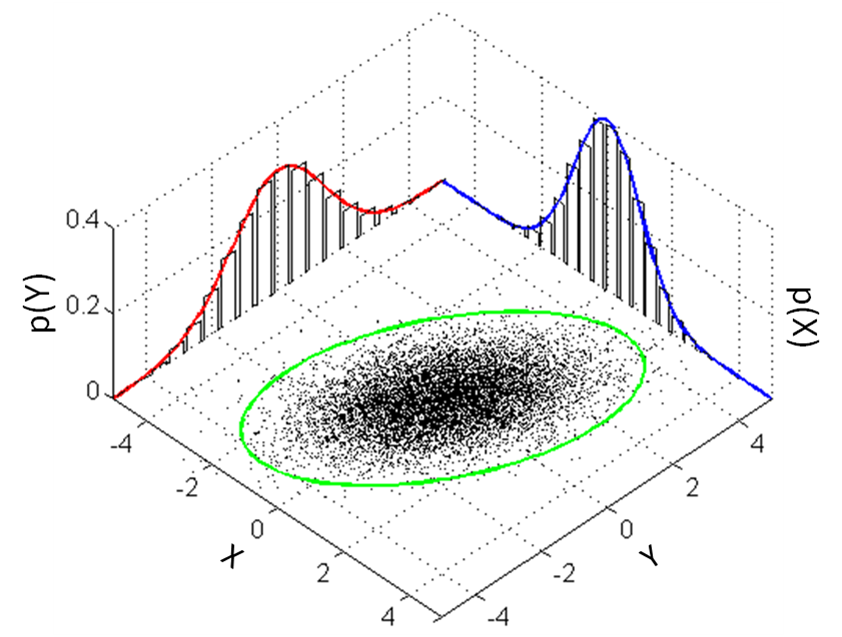

Siguiendo un procedimiento análogo a la regresión kernel univariada, se obtienen los vectores $Y = (y_1, \ldots, y_n)^T$, $\varepsilon = (\varepsilon_1, \ldots, \varepsilon_n)^T$, $\beta = (\beta_0, \ldots, \beta_p)^T$. Se define la matriz de pesos:

$$W_t = \text{Diag}(w(x_1, t), \ldots,
w(x_n, t)).$$

Ajustamos el modelo

$$Y = X \beta + \varepsilon$$

por mínimos cuadrados ponderados :

$$\hat{\beta} = \arg \min_{\beta \in
\mathbb{R}^{p+1}} (Y - X_t \beta)^T W_t (Y - X_t \beta).$$

La solución es

$$\hat{\beta} = \left( X_t^T W_t X_t
\right)^{-1} X_t^T W_t Y.$$

La estimacion en el punto $t$, siguiendo la idea del caso univariado es

$$\hat{m}(t)=\hat{m}(t_1,\dots,t_p)=\beta_0$$

### 4.2 Diseño de kernels en grafos

El diseño del kernel en grafos debe describir la **similitud** entre los vértices en el grafo $G$, así la función Kernel $K$

- $$K: V \times V \to \mathbb{R}$$
- para cada $m = 1, \ldots, N_v$ y subconjunto de vértices $\{i_1, \ldots, i_m\} \in V$, la matriz $m \times m$
  $$\mathbf{K}^{(m)} = [K(i_j, i_{j'})]$$

es **simétrica** y **semidefinida positiva.**

Aunque la proximidad de los vértices está codificada en la matriz de adyacencia , es más común ver el grafo laplaciano *L* usado en la regresión kernel.

$$d_i = \sum_{j} a_{i,j}.$$

$$a_{i,j} = y_{i,j} - \frac{1}{2m} d_i d_j.$$

Así, $L=\phi\Gamma\phi^T$, de la descomposición espectral de $L$. Entonces, la inversa generalizada de esta está dada por

$$L^- = \sum_{i=1}^{N_v} f(\gamma_i)
\phi_i \phi_i^T$$

donde $\phi_i$ es la $i$-ésima columna de $\phi$ y

$$f(\gamma) = \begin{cases}
\gamma^{-1} & \text{si } \gamma \neq 0, \\
0 & \text{en otro caso.}
\end{cases}$$

### 4.3 Regresión kernel en grafos.

Sea $G = (V, E)$ un grafo y $X = (X_1, \dots, X_{N_V})$ un proceso sobre un atributo nodal y sea $V^{obs}$ los nodos los cuales se conoce su atributo . Desde la perspectiva de la regresión Kernel, el objetivo es aprender de los datos sobre una función apropiada $\hat{h} \in \mathbb{R}^{N_V}$, que mapea de $V$ a $\mathbb{R}$, y que describa bien la manera en que los atributos varían entre los vértices. Más precisamente, dado un Kernel $K = \phi \Delta \phi$, se busca encontrar una elección óptima de $h$ dentro de la clase:

$$\mathbb{H}_K = \{ h : h = \phi \beta \text{ tal que } \beta^T
\Delta^{-1} \beta < \infty \}$$

cuando $h$ es un vector de longitud $|N_V|$.

Para elegir un elemento $h$ apropiado en $\mathbb{H}_K$, denominado $\hat{h}$, se emplea una estrategia de **regresión penalizada**. Así, se obtiene que $\hat{h} = \phi \hat{\beta}$ minimizando con respecto a $\beta$:

$$\min_{\beta} \left[\sum_{i \in V^{obs}}
C(x_i; \hat{h}) + \lambda \beta^T \Delta^{-1} \beta\right]$$

donde:

- $V^{obs}$ son los vértices observados.
- $C(x; h) = [\max(0, 1 - (2x - 1)h)]^2$ o una función convexa que mida la *pérdida* de la predicción.
- $\lambda$ controla la importancia de la penalización por la complejidad del modelo y normalmente se elige en función de los datos.

### 4.4 Ejemplo red de proteínas y Método Kernel

```r
suppressMessages(suppressWarnings(library(kernlab)))
```

```r
# matriz laplaciana
L <- as.matrix(laplacian_matrix(ppi.CC.gc))
# descomposición propia de la matriz laplaciana
e.L <- eigen(L)
# numero de vertices en la componente gigante
nv <- vcount(ppi.CC.gc)
# como es conectada únicamente el último valor es cero
e.vals <- e.L$values[1:(nv-1)]
# se hace la inversa generalizada
f.e.vals <- c((e.vals)^(-1), 0)
# último valor propio
e.vals[nv]
```

```
## [1] NA
```

```r
# se construye el kernel
K1.tmp <- e.L$vectors %*% diag(f.e.vals) %*%
  t(e.L$vectors)
K1 <- as.kernelMatrix(K1.tmp)
```

```r
# se genera otro kernel con los motifs
K.motifs <- gene.motifs %*% t(gene.motifs)
```

```r
# se suman ambos kernel para crear uno solo que tenga en cuenta tanto los motif como la matriz L
K2.tmp <- 0.5 * K1.tmp + 0.5 * K.motifs
K2 <- as.kernelMatrix(K2.tmp)
```

```r
# indica el modelo, se utiliza C-svc porque es clasificacion y el tipo de minimización que se hace coincida con
# la propuesta
m1.svm <- ksvm(K1, X, type="C-svc")
# valores ajustados
m1.svm.fitted <- fitted(m1.svm)
```

```r
# tasa de error
mean(as.numeric(m1.svm.fitted != V(ppi.CC.gc)$ICSC))
```

```
## [1] 0.1102362
```

```r
# predicción
m1.svm.fitted[V(ppi.CC.gc)$name %in% new.icsc]
```

```
## [1] 1 1 1 0 0 0 0 0
```

```r
# tasa de error
m2.svm <- ksvm(K2, X, type="C-svc")
```

```r
m2.svm.fitted <- fitted(m2.svm)
mean(as.numeric(m2.svm.fitted != V(ppi.CC.gc)$ICSC))
```

```
## [1] 0.06299213
```

```r
# tasa de error
m2.svm.fitted[V(ppi.CC.gc)$name %in% new.icsc]
```

```
## [1] 1 0 0 0 0 0 0 0
```

## 5 Modelado y predicción de procesos dinámicos

Como se señaló anteriormente, muchos procesos definidos en redes se consideran como procesos dinámicos, como por ejemplo:

- Un rumor que se difunde entre una población.
- virus que se propaga a través de una población de humanos o computadoras.
- un motor de búsqueda que formula una respuesta a una consulta.
- Un proceso en el cerebro y la conexión en las neuronas

Conceptualmente, se pueden pensar estos procesos como procesos de atributos nodales indexados en el tiempo $X(t) = (X_i(t))_{i \in V}$, donde $t$ varía de manera discreta o continua en un rango de tiempos. Se dará un vistazo rápido al modelado y simulación de dichos procesos de una clase particular: los procesos epidémicos.

### 5.1 Modelo tradicional epidémico

Un modelo clásico epidémico tradicional, no relacionado con redes, de tiempo continuo se denomina “**susceptibles**, **infectados**, **recuperados**” (SIR), posiblemente el miembro más simple de esta clase: el llamado modelo epidemiológico general. Para trabajar con este modelo se supone lo siguiente:

- Hay una población cerrada de $N+1$ individuos.
- En cualquier momento $t$, hay un número aleatorio $N_{S}(t)$ de elementos **susceptibles** a la infección.
- En el momento $t$, $N_{I}(t)$ elementos son **infectados**.
- En el momento $t$, $N_{R}(t)$ elementos **recuperados** e inmunes o removidos de la población.
- La población es homogénea y bien mezclada, es decir, cualquier par de miembros tiene la misma probabilidad de interactuar entre sí.

Las probabilidades infinitesimales de transición de $(N_{S}(t), N_{I}(t), N_{R}(t))$ son:

$$\begin{aligned}
\mathbb{P}\left(N_S(t+\delta t)=s-1, N_I(t+\delta t)=i+1 \mid N_S(t)=s,
N_I(t)=i\right) &\approx \beta s i \delta t \\
\mathbb{P}\left(N_S(t+\delta t)=s, N_I(t+\delta t)=i-1 \mid N_S(t)=s,
N_I(t)=i\right) &\approx \gamma i \delta t \\
\mathbb{P}\left(N_S(t+\delta t)=s, N_I(t+\delta t)=i \mid N_S(t)=s,
N_I(t)=i\right) &\approx 1-(\beta s + \gamma) i \delta t \\
\end{aligned}$$

- $\delta t$ es un intervalo $t$ infinitesimal.
- $\beta$ es la tasa de infección.
- $\gamma$ es la tasa recuperación.
- $s$ es el número de **susceptibles**.
- $i$ es el número de **infectados**.

### 5.2 Modelado de epidemias basado en redes

Sea $G$ una red que describe la estructura de contacto de $N_v$ elementos en una población. Supóngase que:

- En el instante $t=0$, un nodo está **infectado** y el resto son **susceptibles**.
- Los vértices infectados permanecen **infectados** durante un tiempo distribuido exponencialmente, con una tasa $\gamma$, después del cual se consideran **recuperados**.
- Durante el período de infección, un vértice tiene contacto de manera independiente con cada vecino, con una probabilidad $\beta$, donde un contacto automáticamente resulta en **infección** si el otro individuo es **susceptible**.
- Se define $X_i(t)=0,1,2$ si el vértice $i$ es **susceptible**, **infectado** o es **removido** en el tiempo $t$.
- Los cambios ocurren en uno y solo un elemento a la vez.

El modelo que se describe es equivalente a especificar que:

$$\mathbb{P}\left(\mathbf{X}(t+\delta t)=\mathbf{x}^{\prime} \mid
\mathbf{X}(t)=\mathbf{x}\right) \approx
\begin{cases}
\beta M_i(\mathbf{x}) \delta t, & \text{si } x_i=0 \text{ y }
x_i^{\prime}=1, \\
\gamma \delta t, & \text{si } x_i=1 \text{ y } x_i^{\prime}=2, \\
1-\left[\beta M_i(\mathbf{x})+\gamma\right] \delta t, & \text{si }
x_i=2 \text{ y } x_i^{\prime}=2,
\end{cases}$$

- $M_i(\mathbf{x})$ es el número de vecinos de $i$ infectados en el momento $t$.

### 5.3 Simulación

**ER (Erdős–Rényi):** Cada par de nodos tiene una probabilidad fija de estar conectado. Este modelo genera redes con una distribución de grado que sigue una distribución de Poisson, donde la mayoría de los nodos tienen un número similar de conexiones.

**BA (Barabási–Albert):** Modelo de red de preferencia preferencial o “rich-get-richer”, donde los nodos con más conexiones tienen mayor probabilidad de recibir nuevas conexiones. Esto genera redes con una estructura de “cola larga”, con unos pocos nodos altamente conectados (hubs) y muchos nodos con pocas conexiones.

**WS (Watts–Strogatz):** Un modelo de red de pequeño mundo que comienza con un anillo regular y luego se agregan aleatoriamente atajos entre nodos. Esto produce redes que combinan alta agrupación local con un bajo número de pasos entre cualquier par de nodos (pequeña distancia promedio).

```r
set.seed(42)
gl <- list()
# se generan 3 tipos de grafos aleatorios con el mismo numero de nodos
gl$ba <- sample_pa(250, m=5, directed=FALSE)
gl$er <- sample_gnm(250, 1250)
gl$ws <- sample_smallworld(1, 250, 5, 0.01)
```

```r
# tasa de infección y recuperación
beta <- 0.5
gamma <- 1
```

```r
# Se utiliza la función Sir de igraph para simular epidemias en cada red.
ntrials <- 100
sim <- lapply(gl, sir, beta=beta, gamma=gamma,
              no.sim=ntrials)
```

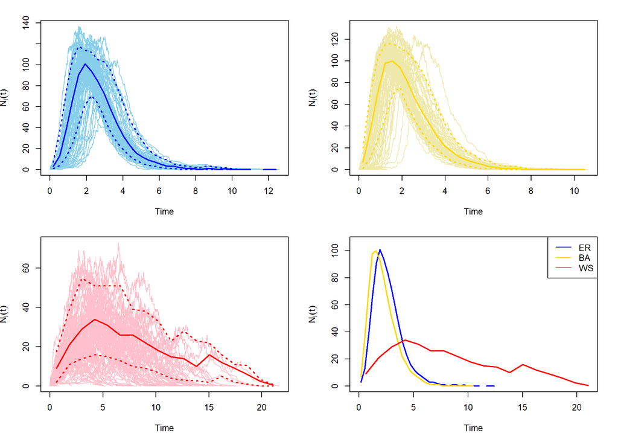

```r
# Calcular x.max e y.max para el gráfico combinado
x.max <- max(sapply(sapply(sim, time_bins), max))
y.max <- 1.05 * max(sapply(sapply(sim, function(x)
  median(x)[["NI"]]), max, na.rm=TRUE))

par(mfrow = c(2,2), mar=c(4, 4, 2, 2))

# Gráfico 1: ER
plot(sim$er)

# Gráfico 2: BA
plot(sim$ba, color = "palegoldenrod",
     median_color = "gold", quantile_color = "gold")

# Gráfico 3: WS
plot(sim$ws, color = "pink", median_color = "red",
     quantile_color = "red")

# Gráfico 4: Líneas superpuestas
plot(time_bins(sim$er), median(sim$er)[["NI"]],
     type="l", lwd=2, col="blue", xlim=c(0, x.max),
     ylim=c(0, y.max), xlab="Time",
     ylab=expression(N[I](t)))
lines(time_bins(sim$ba), median(sim$ba)[["NI"]],
      lwd=2, col="gold")
lines(time_bins(sim$ws), median(sim$ws)[["NI"]],
      lwd=2, col="red")
legend("topright", c("ER", "BA", "WS"),
       col=c("blue", "gold", "red"), lty=1)
```

En cada panel se muestran las trayectorias de simulación individuales, así como sus medianas y sus cuantiles 10 y 90%.

[figure not shown]

Las realizaciones del número de infectados $N_{I}(t)$ para el proceso SIR basado en una red simulada en un grafo aleatorio de Erdos-Renyi (azul), grafo aleatorio de Barabasi-Albert (amarillo) y un grafo aleatorio mundo pequeño de Watts-Strogatz (rojo).

## Referencias:

[figure not shown]

[figure not shown]